# The Pumpkins Example

Alexandra Chronopoulou

LEcture 13

## The Chicago Pumpkins Data Set

The `pumpkins.csv` data set contains information regarding the `size` and `price` of pumpkins sold in the Chicago area. Our goal in this example is to **predict** the size of the pumpkin (response) based on its price (predictor).

```r
pumpkins = read.csv("chicagopumpkins.csv",header=TRUE)
dim(pumpkins)
```

```
## [1] 248   2
```

We start by plotting the data:

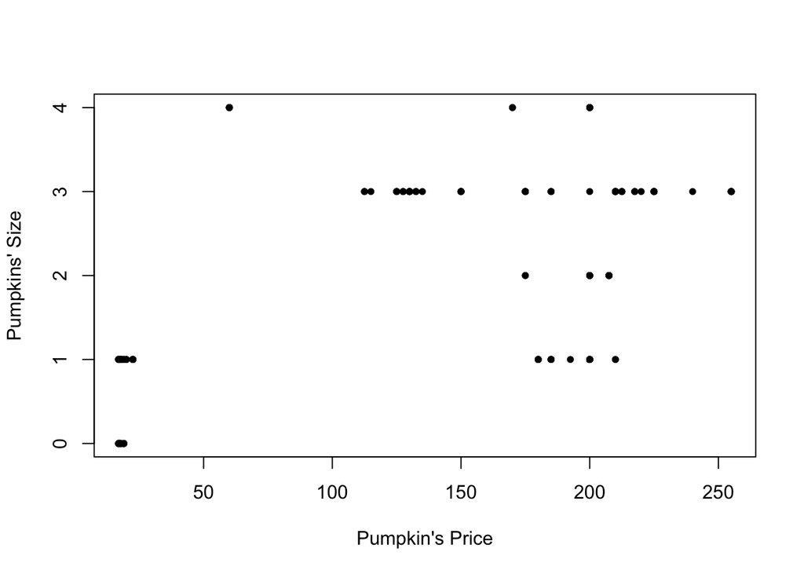

```r
plot(pumpkins$price, pumpkins$size, pch=20, xlab="Pumpkin's Price", ylab="Pumpkins' Size")
```

We see that a linear fit is probably not a good idea. Indeed,

```r
model = lm(size ~ price, data=pumpkins)
summary(model)
```

```
##
## Call:
## lm(formula = size ~ price, data = pumpkins)
##
## Residuals:
##     Min      1Q  Median      3Q     Max
## -1.6272 -0.7594  0.2244  0.3728  2.8245
##
## Coefficients:
##              Estimate Std. Error t value Pr(>|t|)
## (Intercept) 0.5948315  0.0988339   6.018 6.35e-09 ***
## price       0.0096781  0.0006856  14.117  < 2e-16 ***
## ---
## Signif. codes:  0 '***' 0.001 '**' 0.01 '*' 0.05 '.' 0.1 ' ' 1
##
## Residual standard error: 0.9477 on 246 degrees of freedom
## Multiple R-squared:  0.4475, Adjusted R-squared:  0.4453
## F-statistic: 199.3 on 1 and 246 DF,  p-value: < 2.2e-16
```

Although the predictor is significant at explaining the response, the $R^2$ is on the lower end and the scatter plot does not support a straight line as a good fit.

So, we are going to use polynomial regression.

### Polynomials Regression

The model we want to fit looks as follows:
$$y_i = \beta_0 + \beta_1 x + \beta_2 x^2 + \ldots + \beta_d x^d + \varepsilon_i$$

So, we need to select $d$. We start with a **Forward Selection** approach. That is we start by a linear model, and we keep adding terms until the added term becomes statistically insignificant.

```r
# Forward Selection
model0 =  lm(size ~ price , data=pumpkins)
summary(model0)
```

```
##
## Call:
## lm(formula = size ~ price, data = pumpkins)
##
## Residuals:
##     Min      1Q  Median      3Q     Max
## -1.6272 -0.7594  0.2244  0.3728  2.8245
##
## Coefficients:
##              Estimate Std. Error t value Pr(>|t|)
## (Intercept) 0.5948315  0.0988339   6.018 6.35e-09 ***
## price       0.0096781  0.0006856  14.117  < 2e-16 ***
## ---
## Signif. codes:  0 '***' 0.001 '**' 0.01 '*' 0.05 '.' 0.1 ' ' 1
##
## Residual standard error: 0.9477 on 246 degrees of freedom
## Multiple R-squared:  0.4475, Adjusted R-squared:  0.4453
## F-statistic: 199.3 on 1 and 246 DF,  p-value: < 2.2e-16
```

```r
model1 =  lm(size ~ price + I(price^2), data=pumpkins)
summary(model1)
```

```
##
## Call:
## lm(formula = size ~ price + I(price^2), data = pumpkins)
##
## Residuals:
##     Min      1Q  Median      3Q     Max
## -1.6438 -0.6029  0.3695  0.4895  2.3941
##
## Coefficients:
##               Estimate Std. Error t value Pr(>|t|)
## (Intercept)  1.093e-01  1.174e-01   0.932    0.353
## price        3.037e-02  3.208e-03   9.469  < 2e-16 ***
## I(price^2)  -9.051e-05  1.375e-05  -6.582  2.8e-10 ***
## ---
## Signif. codes:  0 '***' 0.001 '**' 0.01 '*' 0.05 '.' 0.1 ' ' 1
##
## Residual standard error: 0.8754 on 245 degrees of freedom
## Multiple R-squared:  0.5305, Adjusted R-squared:  0.5267
## F-statistic: 138.4 on 2 and 245 DF,  p-value: < 2.2e-16
```

```r
model2 =  lm(size ~ price + I(price^2) + I(price^3), data=pumpkins)
summary(model2)
```

```
##
## Call:
## lm(formula = size ~ price + I(price^2) + I(price^3), data = pumpkins)
##
## Residuals:
##     Min      1Q  Median      3Q     Max
## -1.2786 -0.4937 -0.1368  0.5531  1.8633
##
## Coefficients:
##               Estimate Std. Error t value Pr(>|t|)
## (Intercept) -1.414e+00  1.691e-01   -8.36 4.83e-15 ***
## price        1.256e-01  9.079e-03   13.83  < 2e-16 ***
## I(price^2)  -9.845e-04  8.239e-05  -11.95  < 2e-16 ***
## I(price^3)   2.228e-06  2.034e-07   10.95  < 2e-16 ***
## ---
## Signif. codes:  0 '***' 0.001 '**' 0.01 '*' 0.05 '.' 0.1 ' ' 1
##
## Residual standard error: 0.7182 on 244 degrees of freedom
## Multiple R-squared:  0.6853, Adjusted R-squared:  0.6814
## F-statistic: 177.1 on 3 and 244 DF,  p-value: < 2.2e-16
```

```r
model3 =  lm(size ~ price + I(price^2) + I(price^3) + I(price^4), data=pumpkins)
summary(model3)
```

```
##
## Call:
## lm(formula = size ~ price + I(price^2) + I(price^3) + I(price^4),
##     data = pumpkins)
##
## Residuals:
##     Min      1Q  Median      3Q     Max
## -1.3200 -0.4497 -0.1241  0.5539  1.7925
##
## Coefficients:
##               Estimate Std. Error t value Pr(>|t|)
## (Intercept) -2.871e+00  3.782e-01  -7.590 6.83e-13 ***
## price        2.314e-01  2.630e-02   8.800 2.60e-16 ***
## I(price^2)  -2.565e-03  3.785e-04  -6.776 9.25e-11 ***
## I(price^3)   1.061e-05  1.973e-06   5.378 1.76e-07 ***
## I(price^4)  -1.470e-08  3.443e-09  -4.271 2.80e-05 ***
## ---
## Signif. codes:  0 '***' 0.001 '**' 0.01 '*' 0.05 '.' 0.1 ' ' 1
##
## Residual standard error: 0.6941 on 243 degrees of freedom
## Multiple R-squared:  0.7073, Adjusted R-squared:  0.7025
## F-statistic: 146.8 on 4 and 243 DF,  p-value: < 2.2e-16
```

```r
model4 =  lm(size ~ price + I(price^2) + I(price^3) + I(price^4)+ I(price^5), data=pumpkins)
summary(model4)
```

```
##
## Call:
## lm(formula = size ~ price + I(price^2) + I(price^3) + I(price^4) +
##     I(price^5), data = pumpkins)
##
## Residuals:
##      Min       1Q   Median       3Q      Max
## -1.38082 -0.46537 -0.08211  0.53463  1.91954
##
## Coefficients:
##               Estimate Std. Error t value Pr(>|t|)
## (Intercept) -1.691e+00  7.112e-01  -2.378   0.0182 *
## price        1.305e-01  5.791e-02   2.253   0.0251 *
## I(price^2)  -2.479e-04  1.244e-03  -0.199   0.8422
## I(price^3)  -1.078e-05  1.113e-05  -0.969   0.3333
## I(price^4)   7.118e-08  4.409e-08   1.615   0.1077
## I(price^5)  -1.248e-10  6.386e-11  -1.954   0.0519 .
## ---
## Signif. codes:  0 '***' 0.001 '**' 0.01 '*' 0.05 '.' 0.1 ' ' 1
##
## Residual standard error: 0.6901 on 242 degrees of freedom
## Multiple R-squared:  0.7118, Adjusted R-squared:  0.7059
## F-statistic: 119.6 on 5 and 242 DF,  p-value: < 2.2e-16
```

We see that the 5th order model has a 5th order term with $p$-value equal to 0.0519, which is higher than 5%, so we conclude that the optimal order for the polynomial, according to the forward selection method is $d=4$. So, the fitted model is:
$$\hat{y}_i = \hat{\beta}_0 + \hat{\beta}_1 x + \hat{\beta}_2 x^2 + \hat{\beta}_3 x^4 + \hat{\beta}_4 x^4$$

If we plot all the fitted models, we have:

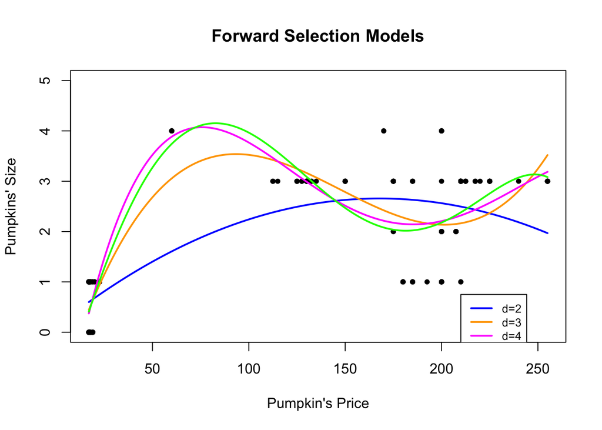

```r
newprice = data.frame(price=seq(17, 255, 1))
plot(pumpkins$price, pumpkins$size, pch=20, ylim=c(0,5), xlab="Pumpkin's Price", ylab="Pumpkins' Size", main="Forward Selection Models")
lines(newprice$price, predict(model1, newprice), col="blue", lty=1, lwd=2);
lines(newprice$price, predict(model2, newprice), col="orange", lty=1, lwd=2);
lines(newprice$price, predict(model3, newprice), col="magenta", lty=1, lwd=2);
lines(newprice$price, predict(model4, newprice), col="green", lty=1, lwd=2);
legend(210, 0.75, legend=c("d=2", "d=3", "d=4", "d=5"),
       col=c("blue", "orange", "magenta", "green"), lty=c(1,1,1,1), cex=0.8, lwd=c(2,2,2,2))
```

The magenta line is the one that corresponds to the 4th order model.

We can also select $d$ using the **Backward Elimination** approach. So, we start with a large value for $d$ and we eliminate terms until all the terms in the model are statistically significant:

```r
model_1 =  lm(size ~ price + I(price^2) + I(price^3) + I(price^4)+ I(price^5)+ I(price^6) + I(price^7)+ I(price^8)+ I(price^9)+ I(price^10), data=pumpkins)
summary(model_1)
```

```
##
## Call:
## lm(formula = size ~ price + I(price^2) + I(price^3) + I(price^4) +
##     I(price^5) + I(price^6) + I(price^7) + I(price^8) + I(price^9) +
##     I(price^10), data = pumpkins)
##
## Residuals:
##      Min       1Q   Median       3Q      Max
## -1.44082 -0.45530 -0.01853  0.53535  2.12546
##
## Coefficients:
##               Estimate Std. Error t value Pr(>|t|)
## (Intercept)  1.331e+01  2.671e+01   0.498    0.619
## price       -2.191e+00  4.274e+00  -0.513    0.609
## I(price^2)   1.396e-01  2.625e-01   0.532    0.595
## I(price^3)  -4.389e-03  8.140e-03  -0.539    0.590
## I(price^4)   8.198e-05  1.458e-04   0.562    0.575
## I(price^5)  -9.818e-07  1.624e-06  -0.605    0.546
## I(price^6)   7.731e-09  1.163e-08   0.664    0.507
## I(price^7)  -3.970e-11  5.374e-11  -0.739    0.461
## I(price^8)   1.276e-13  1.549e-13   0.824    0.411
## I(price^9)  -2.321e-16  2.535e-16  -0.916    0.361
## I(price^10)  1.821e-19  1.800e-19   1.012    0.313
##
## Residual standard error: 0.6483 on 237 degrees of freedom
## Multiple R-squared:  0.7509, Adjusted R-squared:  0.7404
## F-statistic: 71.45 on 10 and 237 DF,  p-value: < 2.2e-16
```

```r
model_2 =  lm(size ~ price + I(price^2) + I(price^3) + I(price^4)+ I(price^5)+ I(price^6) + I(price^7)+ I(price^8)+ I(price^9), data=pumpkins)
summary(model_2)
```

```
##
## Call:
## lm(formula = size ~ price + I(price^2) + I(price^3) + I(price^4) +
##     I(price^5) + I(price^6) + I(price^7) + I(price^8) + I(price^9),
##     data = pumpkins)
##
## Residuals:
##     Min      1Q  Median      3Q     Max
## -1.4514 -0.4230 -0.0091  0.5177  2.1072
##
## Coefficients:
##               Estimate Std. Error t value Pr(>|t|)
## (Intercept) -1.191e+01  9.589e+00  -1.242   0.2154
## price        1.877e+00  1.450e+00   1.295   0.1967
## I(price^2)  -1.125e-01  8.271e-02  -1.360   0.1751
## I(price^3)   3.506e-03  2.316e-03   1.514   0.1314
## I(price^4)  -6.094e-05  3.623e-05  -1.682   0.0939 .
## I(price^5)   6.252e-07  3.391e-07   1.844   0.0664 .
## I(price^6)  -3.875e-09  1.945e-09  -1.993   0.0475 *
## I(price^7)   1.425e-11  6.704e-12   2.125   0.0346 *
## I(price^8)  -2.859e-14  1.276e-14  -2.241   0.0259 *
## I(price^9)   2.411e-17  1.030e-17   2.340   0.0201 *
## ---
## Signif. codes:  0 '***' 0.001 '**' 0.01 '*' 0.05 '.' 0.1 ' ' 1
##
## Residual standard error: 0.6483 on 238 degrees of freedom
## Multiple R-squared:  0.7499, Adjusted R-squared:  0.7404
## F-statistic: 79.27 on 9 and 238 DF,  p-value: < 2.2e-16
```

```r
model_3 =  lm(size ~ price + I(price^2) + I(price^3)+ I(price^4)+ I(price^5)+ I(price^6) + I(price^7)+ I(price^8), data=pumpkins)
summary(model_3)
```

```
##
## Call:
## lm(formula = size ~ price + I(price^2) + I(price^3) + I(price^4) +
##     I(price^5) + I(price^6) + I(price^7) + I(price^8), data = pumpkins)
##
## Residuals:
##      Min       1Q   Median       3Q      Max
## -1.39988 -0.45678 -0.05827  0.53309  2.02119
##
## Coefficients:
##               Estimate Std. Error t value Pr(>|t|)
## (Intercept)  9.140e+00  3.347e+00   2.731 0.006791 **
## price       -1.368e+00  4.257e-01  -3.215 0.001486 **
## I(price^2)   7.522e-02  2.032e-02   3.702 0.000266 ***
## I(price^3)  -1.798e-03  4.783e-04  -3.759 0.000214 ***
## I(price^4)   2.262e-05  6.154e-06   3.675 0.000293 ***
## I(price^5)  -1.611e-07  4.541e-08  -3.549 0.000466 ***
## I(price^6)   6.535e-10  1.918e-10   3.407 0.000771 ***
## I(price^7)  -1.406e-12  4.316e-13  -3.259 0.001282 **
## I(price^8)   1.246e-15  4.008e-16   3.108 0.002112 **
## ---
## Signif. codes:  0 '***' 0.001 '**' 0.01 '*' 0.05 '.' 0.1 ' ' 1
##
## Residual standard error: 0.6544 on 239 degrees of freedom
## Multiple R-squared:  0.7441, Adjusted R-squared:  0.7355
## F-statistic: 86.87 on 8 and 239 DF,  p-value: < 2.2e-16
```

Starting with an order 10 model, we identify that an 8th order model is optimal according to the backward elimination criterion. If we plot all the fitted models, we have:

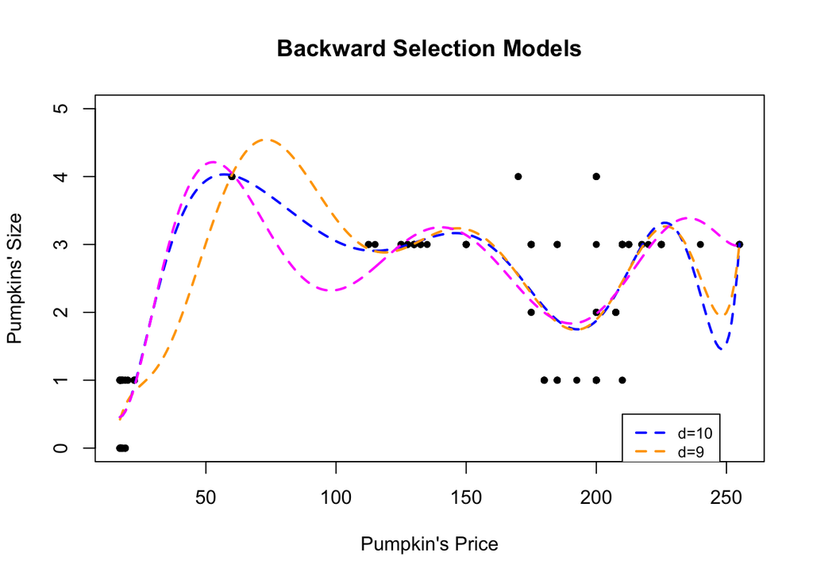

```r
newprice = data.frame(price=seq(17, 255, 1))
plot(pumpkins$price, pumpkins$size, ylim=c(0,5), pch=20, xlab="Pumpkin's Price", ylab="Pumpkins' Size", main="Backward Selection Models")
lines(newprice$price, predict(model_1, newprice), col="blue", lty=2, lwd=2);
lines(newprice$price, predict(model_2, newprice), col="orange", lty=2, lwd=2);
lines(newprice$price, predict(model_3, newprice), col="magenta", lty=2, lwd=2);
legend(210, 0.5, legend=c("d=10", "d=9", "d=8"),
       col=c("blue", "orange", "magenta"), lty=c(2,2,2), cex=0.8, lwd=2)
```

The magenta line is the one that corresponds to the 8th order model.

#### Orthogonal Polynomials

We discussed that when there is a need to fit higher order polynomials, our results might be unstable. For that reason, it is preferred to work with **orthogonal** polynomials, that is polynomials whose coefficients inner product is zero.

In R, we can do this using the `poly` functions. In the code below, we repeat the same process as above (for choosing $d$) using the orthogonal polynomials.

```r
# Forward Selection
model1s =  lm(size ~ poly(price,2), data=pumpkins)
summary(model1s)
```

```
##
## Call:
## lm(formula = size ~ poly(price, 2), data = pumpkins)
##
## Residuals:
##     Min      1Q  Median      3Q     Max
## -1.6438 -0.6029  0.3695  0.4895  2.3941
##
## Coefficients:
##                 Estimate Std. Error t value Pr(>|t|)
## (Intercept)      1.70161    0.05559  30.612  < 2e-16 ***
## poly(price, 2)1 13.37846    0.87538  15.283  < 2e-16 ***
## poly(price, 2)2 -5.76139    0.87538  -6.582  2.8e-10 ***
## ---
## Signif. codes:  0 '***' 0.001 '**' 0.01 '*' 0.05 '.' 0.1 ' ' 1
##
## Residual standard error: 0.8754 on 245 degrees of freedom
## Multiple R-squared:  0.5305, Adjusted R-squared:  0.5267
## F-statistic: 138.4 on 2 and 245 DF,  p-value: < 2.2e-16
```

```r
model2s =  lm(size ~ poly(price,3), data=pumpkins)
summary(model2s)
```

```
##
## Call:
## lm(formula = size ~ poly(price, 3), data = pumpkins)
##
## Residuals:
##     Min      1Q  Median      3Q     Max
## -1.2786 -0.4937 -0.1368  0.5531  1.8633
##
## Coefficients:
##                 Estimate Std. Error t value Pr(>|t|)
## (Intercept)       1.7016     0.0456  37.313  < 2e-16 ***
## poly(price, 3)1  13.3785     0.7182  18.628  < 2e-16 ***
## poly(price, 3)2  -5.7614     0.7182  -8.022 4.35e-14 ***
## poly(price, 3)3   7.8672     0.7182  10.954  < 2e-16 ***
## ---
## Signif. codes:  0 '***' 0.001 '**' 0.01 '*' 0.05 '.' 0.1 ' ' 1
##
## Residual standard error: 0.7182 on 244 degrees of freedom
## Multiple R-squared:  0.6853, Adjusted R-squared:  0.6814
## F-statistic: 177.1 on 3 and 244 DF,  p-value: < 2.2e-16
```

```r
model3s =  lm(size ~ poly(price,4), data=pumpkins)
summary(model3s)
```

```
##
## Call:
## lm(formula = size ~ poly(price, 4), data = pumpkins)
##
## Residuals:
##     Min      1Q  Median      3Q     Max
## -1.3200 -0.4497 -0.1241  0.5539  1.7925
##
## Coefficients:
##                 Estimate Std. Error t value Pr(>|t|)
## (Intercept)      1.70161    0.04407  38.608  < 2e-16 ***
## poly(price, 4)1 13.37846    0.69408  19.275  < 2e-16 ***
## poly(price, 4)2 -5.76139    0.69408  -8.301 7.22e-15 ***
## poly(price, 4)3  7.86718    0.69408  11.335  < 2e-16 ***
## poly(price, 4)4 -2.96423    0.69408  -4.271 2.80e-05 ***
## ---
## Signif. codes:  0 '***' 0.001 '**' 0.01 '*' 0.05 '.' 0.1 ' ' 1
##
## Residual standard error: 0.6941 on 243 degrees of freedom
## Multiple R-squared:  0.7073, Adjusted R-squared:  0.7025
## F-statistic: 146.8 on 4 and 243 DF,  p-value: < 2.2e-16
```

```r
model4s =  lm(size ~ poly(price,5), data=pumpkins)
summary(model4s)
```

```
##
## Call:
## lm(formula = size ~ poly(price, 5), data = pumpkins)
##
## Residuals:
##      Min       1Q   Median       3Q      Max
## -1.38082 -0.46537 -0.08211  0.53463  1.91954
##
## Coefficients:
##                 Estimate Std. Error t value Pr(>|t|)
## (Intercept)      1.70161    0.04382  38.831  < 2e-16 ***
## poly(price, 5)1 13.37846    0.69009  19.387  < 2e-16 ***
## poly(price, 5)2 -5.76139    0.69009  -8.349 5.35e-15 ***
## poly(price, 5)3  7.86718    0.69009  11.400  < 2e-16 ***
## poly(price, 5)4 -2.96423    0.69009  -4.295 2.53e-05 ***
## poly(price, 5)5 -1.34841    0.69009  -1.954   0.0519 .
## ---
## Signif. codes:  0 '***' 0.001 '**' 0.01 '*' 0.05 '.' 0.1 ' ' 1
##
## Residual standard error: 0.6901 on 242 degrees of freedom
## Multiple R-squared:  0.7118, Adjusted R-squared:  0.7059
## F-statistic: 119.6 on 5 and 242 DF,  p-value: < 2.2e-16
```

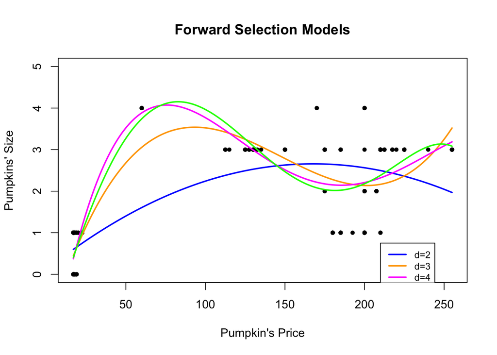

```r
newprice = data.frame(price=seq(17, 255, 1))
plot(pumpkins$price, pumpkins$size, pch=20,  ylim=c(0,5),xlab="Pumpkin's Price", ylab="Pumpkins' Size", main="Forward Selection Models")
lines(newprice$price, predict(model1s, newprice), col="blue", lty=1, lwd=2);
lines(newprice$price, predict(model2s, newprice), col="orange", lty=1, lwd=2);
lines(newprice$price, predict(model3s, newprice), col="magenta", lty=1, lwd=2);
lines(newprice$price, predict(model4s, newprice), col="green", lty=1, lwd=2);
legend(210, 0.75, legend=c("d=2", "d=3", "d=4", "d=5"),
       col=c("blue", "orange", "magenta", "green"), lty=c(1,1,1,1), cex=0.8, lwd=c(2,2,2,2))
```

```r
# Backward Selection
model_1s =  lm(size ~ poly(price,10), data=pumpkins)
summary(model_1s)
```

```
##
## Call:
## lm(formula = size ~ poly(price, 10), data = pumpkins)
##
## Residuals:
##      Min       1Q   Median       3Q      Max
## -1.44082 -0.45530 -0.01853  0.53535  2.12546
##
## Coefficients:
##                   Estimate Std. Error t value Pr(>|t|)
## (Intercept)        1.70161    0.04117  41.335  < 2e-16 ***
## poly(price, 10)1  13.37846    0.64829  20.636  < 2e-16 ***
## poly(price, 10)2  -5.76139    0.64829  -8.887  < 2e-16 ***
## poly(price, 10)3   7.86718    0.64829  12.135  < 2e-16 ***
## poly(price, 10)4  -2.96423    0.64829  -4.572 7.77e-06 ***
## poly(price, 10)5  -1.34841    0.64829  -2.080  0.03861 *
## poly(price, 10)6  -1.45456    0.64829  -2.244  0.02578 *
## poly(price, 10)7  -2.57955    0.64829  -3.979 9.20e-05 ***
## poly(price, 10)8   2.03378    0.64829   3.137  0.00192 **
## poly(price, 10)9   1.51698    0.64829   2.340  0.02012 *
## poly(price, 10)10  0.65591    0.64829   1.012  0.31269
## ---
## Signif. codes:  0 '***' 0.001 '**' 0.01 '*' 0.05 '.' 0.1 ' ' 1
##
## Residual standard error: 0.6483 on 237 degrees of freedom
## Multiple R-squared:  0.7509, Adjusted R-squared:  0.7404
## F-statistic: 71.45 on 10 and 237 DF,  p-value: < 2.2e-16
```

```r
model_2s =  lm(size ~ poly(price,9), data=pumpkins)
summary(model_2s)
```

```
##
## Call:
## lm(formula = size ~ poly(price, 9), data = pumpkins)
##
## Residuals:
##     Min      1Q  Median      3Q     Max
## -1.4514 -0.4230 -0.0091  0.5177  2.1072
##
## Coefficients:
##                 Estimate Std. Error t value Pr(>|t|)
## (Intercept)      1.70161    0.04117  41.333  < 2e-16 ***
## poly(price, 9)1 13.37846    0.64833  20.635  < 2e-16 ***
## poly(price, 9)2 -5.76139    0.64833  -8.887  < 2e-16 ***
## poly(price, 9)3  7.86718    0.64833  12.135  < 2e-16 ***
## poly(price, 9)4 -2.96423    0.64833  -4.572 7.76e-06 ***
## poly(price, 9)5 -1.34841    0.64833  -2.080  0.03861 *
## poly(price, 9)6 -1.45456    0.64833  -2.244  0.02578 *
## poly(price, 9)7 -2.57955    0.64833  -3.979 9.20e-05 ***
## poly(price, 9)8  2.03378    0.64833   3.137  0.00192 **
## poly(price, 9)9  1.51698    0.64833   2.340  0.02012 *
## ---
## Signif. codes:  0 '***' 0.001 '**' 0.01 '*' 0.05 '.' 0.1 ' ' 1
##
## Residual standard error: 0.6483 on 238 degrees of freedom
## Multiple R-squared:  0.7499, Adjusted R-squared:  0.7404
## F-statistic: 79.27 on 9 and 238 DF,  p-value: < 2.2e-16
```

```r
model_3s =  lm(size ~ poly(price,8), data=pumpkins)
summary(model_3s)
```

```
##
## Call:
## lm(formula = size ~ poly(price, 8), data = pumpkins)
##
## Residuals:
##      Min       1Q   Median       3Q      Max
## -1.39988 -0.45678 -0.05827  0.53309  2.02119
##
## Coefficients:
##                 Estimate Std. Error t value Pr(>|t|)
## (Intercept)      1.70161    0.04155  40.951  < 2e-16 ***
## poly(price, 8)1 13.37846    0.65437  20.445  < 2e-16 ***
## poly(price, 8)2 -5.76139    0.65437  -8.805 2.71e-16 ***
## poly(price, 8)3  7.86718    0.65437  12.023  < 2e-16 ***
## poly(price, 8)4 -2.96423    0.65437  -4.530 9.32e-06 ***
## poly(price, 8)5 -1.34841    0.65437  -2.061 0.040421 *
## poly(price, 8)6 -1.45456    0.65437  -2.223 0.027162 *
## poly(price, 8)7 -2.57955    0.65437  -3.942 0.000106 ***
## poly(price, 8)8  2.03378    0.65437   3.108 0.002112 **
## ---
## Signif. codes:  0 '***' 0.001 '**' 0.01 '*' 0.05 '.' 0.1 ' ' 1
##
## Residual standard error: 0.6544 on 239 degrees of freedom
## Multiple R-squared:  0.7441, Adjusted R-squared:  0.7355
## F-statistic: 86.87 on 8 and 239 DF,  p-value: < 2.2e-16
```

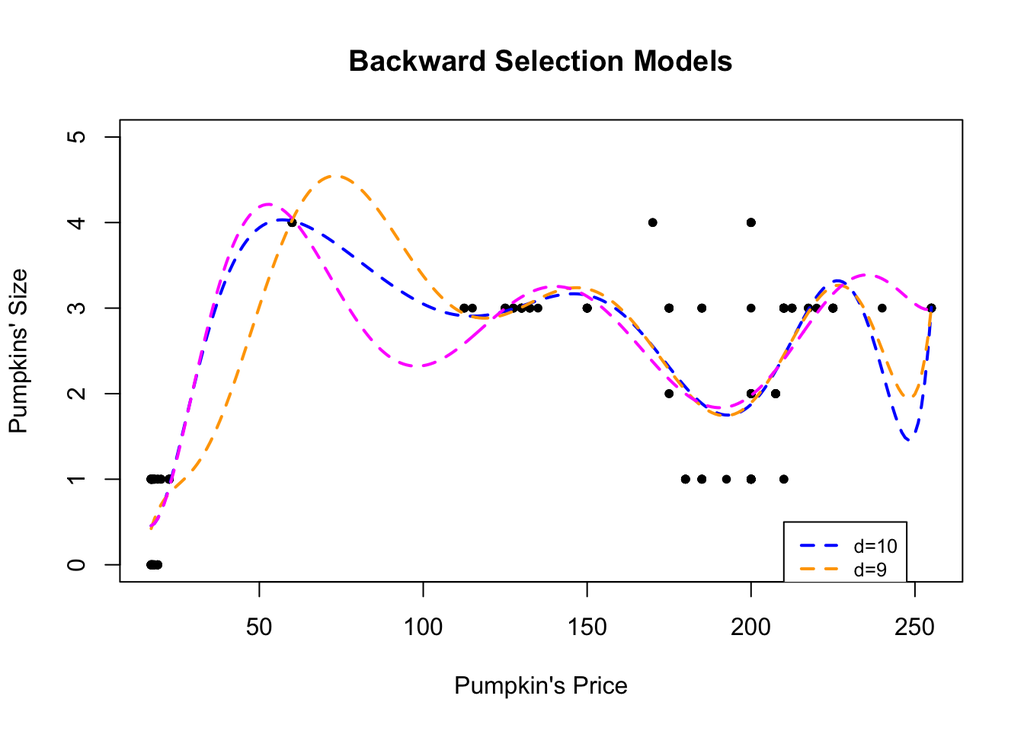

```r
plot(pumpkins$price, pumpkins$size, pch=20, ylim=c(0,5), xlab="Pumpkin's Price", ylab="Pumpkins' Size", main="Backward Selection Models")
lines(newprice$price, predict(model_1s, newprice), col="blue", lty=2, lwd=2);
lines(newprice$price, predict(model_2s, newprice), col="orange", lty=2, lwd=2);
lines(newprice$price, predict(model_3s, newprice), col="magenta", lty=2, lwd=2);
legend(210, 0.5, legend=c("d=10", "d=9", "d=8"),  col=c("blue", "orange", "magenta"), lty=c(2,2,2), cex=0.8, lwd=2)
```

### Splines Regression

Now, let’s try to use different types of Splines basis to fit the pumpkins’ data.

#### B-Splines

We start by fitting a model with B-splines with df=5. Note that we choose `intercept=FALSE` (the default) inside the `bs` function, because an intercept will be automatically added by the `lm` function. If we choose `intercept=TRUE`, then R will not be able to estimate two intercepts and will procude NAs .

```r
library(splines)
pumpkin.bs = lm(size ~ bs(price, df=5, intercept=FALSE), data=pumpkins)
summary(pumpkin.bs)
```

```
##
## Call:
## lm(formula = size ~ bs(price, df = 5, intercept = FALSE), data = pumpkins)
##
## Residuals:
##      Min       1Q   Median       3Q      Max
## -1.40250 -0.49560 -0.06913  0.48870  1.94349
##
## Coefficients:
##                                       Estimate Std. Error t value Pr(>|t|)
## (Intercept)                            0.51654    0.09964   5.184 4.59e-07 ***
## bs(price, df = 5, intercept = FALSE)1 -0.19979    0.16744  -1.193  0.23397
## bs(price, df = 5, intercept = FALSE)2  7.39369    0.54755  13.503  < 2e-16 ***
## bs(price, df = 5, intercept = FALSE)3 -1.34647    0.51698  -2.604  0.00977 **
## bs(price, df = 5, intercept = FALSE)4  2.79392    0.26166  10.677  < 2e-16 ***
## bs(price, df = 5, intercept = FALSE)5  2.55259    0.24564  10.392  < 2e-16 ***
## ---
## Signif. codes:  0 '***' 0.001 '**' 0.01 '*' 0.05 '.' 0.1 ' ' 1
##
## Residual standard error: 0.6846 on 242 degrees of freedom
## Multiple R-squared:  0.7164, Adjusted R-squared:  0.7105
## F-statistic: 122.3 on 5 and 242 DF,  p-value: < 2.2e-16
```

```r
dim(bs(pumpkins$price, df=5, intercept=FALSE))
```

```
## [1] 248   5
```

Below we can see the difference when we have `intercept=TRUE` in the regression function. The NAs generated is because we have two intercepts in the model.

```r
pumpkin.bs = lm(size ~ bs(price, df=5, intercept=TRUE), data=pumpkins)
summary(pumpkin.bs)
```

```
##
## Call:
## lm(formula = size ~ bs(price, df = 5, intercept = TRUE), data = pumpkins)
##
## Residuals:
##     Min      1Q  Median      3Q     Max
## -1.2885 -0.4538 -0.1039  0.5945  1.7875
##
## Coefficients: (1 not defined because of singularities)
##                                      Estimate Std. Error t value Pr(>|t|)
## (Intercept)                            3.2479     0.2202  14.748  < 2e-16 ***
## bs(price, df = 5, intercept = TRUE)1  -2.8658     0.2303 -12.445  < 2e-16 ***
## bs(price, df = 5, intercept = TRUE)2   2.5631     0.5868   4.368 1.86e-05 ***
## bs(price, df = 5, intercept = TRUE)3  -1.3562     0.4737  -2.863 0.004562 **
## bs(price, df = 5, intercept = TRUE)4  -1.3724     0.4048  -3.391 0.000814 ***
## bs(price, df = 5, intercept = TRUE)5       NA         NA      NA       NA
## ---
## Signif. codes:  0 '***' 0.001 '**' 0.01 '*' 0.05 '.' 0.1 ' ' 1
##
## Residual standard error: 0.6983 on 243 degrees of freedom
## Multiple R-squared:  0.7037, Adjusted R-squared:  0.6988
## F-statistic: 144.3 on 4 and 243 DF,  p-value: < 2.2e-16
```

```r
dim(bs(pumpkins$price, df=5, intercept=TRUE))
```

```
## [1] 248   5
```

Now, let us compare B-splines models with different degrees of freedom:

```r
pumpkin.bs1 = lm(size ~ bs(price, df=3, intercept=FALSE), data=pumpkins)
summary(pumpkin.bs1)
```

```
##
## Call:
## lm(formula = size ~ bs(price, df = 3, intercept = FALSE), data = pumpkins)
##
## Residuals:
##     Min      1Q  Median      3Q     Max
## -1.2786 -0.4937 -0.1368  0.5531  1.8633
##
## Coefficients:
##                                       Estimate Std. Error t value Pr(>|t|)
## (Intercept)                            0.44688    0.07231    6.18 2.67e-09 ***
## bs(price, df = 3, intercept = FALSE)1  7.45839    0.51528   14.47  < 2e-16 ***
## bs(price, df = 3, intercept = FALSE)2 -1.52764    0.41063   -3.72 0.000247 ***
## bs(price, df = 3, intercept = FALSE)3  3.07362    0.23033   13.34  < 2e-16 ***
## ---
## Signif. codes:  0 '***' 0.001 '**' 0.01 '*' 0.05 '.' 0.1 ' ' 1
##
## Residual standard error: 0.7182 on 244 degrees of freedom
## Multiple R-squared:  0.6853, Adjusted R-squared:  0.6814
## F-statistic: 177.1 on 3 and 244 DF,  p-value: < 2.2e-16
```

```r
dim(ns(pumpkins$price, df=3))
```

```
## [1] 248   3
```

```r
pumpkin.bs2 = lm(size ~ bs(price, df=4, intercept=FALSE), data=pumpkins)
summary(pumpkin.bs2)
```

```
##
## Call:
## lm(formula = size ~ bs(price, df = 4, intercept = FALSE), data = pumpkins)
##
## Residuals:
##     Min      1Q  Median      3Q     Max
## -1.2885 -0.4538 -0.1039  0.5945  1.7875
##
## Coefficients:
##                                       Estimate Std. Error t value Pr(>|t|)
## (Intercept)                            0.38213    0.07227   5.288 2.76e-07 ***
## bs(price, df = 4, intercept = FALSE)1  5.42888    0.54135  10.028  < 2e-16 ***
## bs(price, df = 4, intercept = FALSE)2  1.50956    0.46843   3.223  0.00144 **
## bs(price, df = 4, intercept = FALSE)3  1.49343    0.26701   5.593 5.99e-08 ***
## bs(price, df = 4, intercept = FALSE)4  2.86578    0.23028  12.445  < 2e-16 ***
## ---
## Signif. codes:  0 '***' 0.001 '**' 0.01 '*' 0.05 '.' 0.1 ' ' 1
##
## Residual standard error: 0.6983 on 243 degrees of freedom
## Multiple R-squared:  0.7037, Adjusted R-squared:  0.6988
## F-statistic: 144.3 on 4 and 243 DF,  p-value: < 2.2e-16
```

```r
dim(ns(pumpkins$price, df=4))
```

```
## [1] 248   4
```

```r
pumpkin.bs3 = lm(size ~ bs(price, df=5, intercept=FALSE), data=pumpkins)
summary(pumpkin.bs3)
```

```
##
## Call:
## lm(formula = size ~ bs(price, df = 5, intercept = FALSE), data = pumpkins)
##
## Residuals:
##      Min       1Q   Median       3Q      Max
## -1.40250 -0.49560 -0.06913  0.48870  1.94349
##
## Coefficients:
##                                       Estimate Std. Error t value Pr(>|t|)
## (Intercept)                            0.51654    0.09964   5.184 4.59e-07 ***
## bs(price, df = 5, intercept = FALSE)1 -0.19979    0.16744  -1.193  0.23397
## bs(price, df = 5, intercept = FALSE)2  7.39369    0.54755  13.503  < 2e-16 ***
## bs(price, df = 5, intercept = FALSE)3 -1.34647    0.51698  -2.604  0.00977 **
## bs(price, df = 5, intercept = FALSE)4  2.79392    0.26166  10.677  < 2e-16 ***
## bs(price, df = 5, intercept = FALSE)5  2.55259    0.24564  10.392  < 2e-16 ***
## ---
## Signif. codes:  0 '***' 0.001 '**' 0.01 '*' 0.05 '.' 0.1 ' ' 1
##
## Residual standard error: 0.6846 on 242 degrees of freedom
## Multiple R-squared:  0.7164, Adjusted R-squared:  0.7105
## F-statistic: 122.3 on 5 and 242 DF,  p-value: < 2.2e-16
```

```r
dim(ns(pumpkins$price, df=5))
```

```
## [1] 248   5
```

```r
pumpkin.bs4 = lm(size ~ bs(price, df=6, intercept=FALSE), data=pumpkins)
summary(pumpkin.bs4)
```

```
##
## Call:
## lm(formula = size ~ bs(price, df = 6, intercept = FALSE), data = pumpkins)
##
## Residuals:
##      Min       1Q   Median       3Q      Max
## -1.41541 -0.52273 -0.00373  0.47727  1.93349
##
## Coefficients:
##                                       Estimate Std. Error t value Pr(>|t|)
## (Intercept)                             0.5227     0.1024   5.102 6.80e-07 ***
## bs(price, df = 6, intercept = FALSE)1  -0.2070     0.1405  -1.474    0.142
## bs(price, df = 6, intercept = FALSE)2   4.7554     0.5660   8.402 3.83e-15 ***
## bs(price, df = 6, intercept = FALSE)3   3.1863     0.4068   7.833 1.51e-13 ***
## bs(price, df = 6, intercept = FALSE)4   0.4282     0.3111   1.377    0.170
## bs(price, df = 6, intercept = FALSE)5   3.2666     0.3605   9.062  < 2e-16 ***
## bs(price, df = 6, intercept = FALSE)6   2.4810     0.2471  10.041  < 2e-16 ***
## ---
## Signif. codes:  0 '***' 0.001 '**' 0.01 '*' 0.05 '.' 0.1 ' ' 1
##
## Residual standard error: 0.6796 on 241 degrees of freedom
## Multiple R-squared:  0.7217, Adjusted R-squared:  0.7148
## F-statistic: 104.2 on 6 and 241 DF,  p-value: < 2.2e-16
```

```r
dim(ns(pumpkins$price, df=6))
```

```
## [1] 248   6
```

```r
pumpkin.bs5 = lm(size ~ bs(price, df=7, intercept=FALSE), data=pumpkins)
summary(pumpkin.bs5)
```

```
##
## Call:
## lm(formula = size ~ bs(price, df = 7, intercept = FALSE), data = pumpkins)
##
## Residuals:
##     Min      1Q  Median      3Q     Max
## -1.4058 -0.5227 -0.0304  0.4773  1.9905
##
## Coefficients:
##                                       Estimate Std. Error t value Pr(>|t|)
## (Intercept)                             0.5227     0.1017   5.138 5.76e-07 ***
## bs(price, df = 7, intercept = FALSE)1  -0.2275     0.1883  -1.208    0.228
## bs(price, df = 7, intercept = FALSE)2   0.1074     0.2116   0.507    0.612
## bs(price, df = 7, intercept = FALSE)3   5.7142     0.6461   8.844  < 2e-16 ***
## bs(price, df = 7, intercept = FALSE)4   2.0076     0.4199   4.781 3.05e-06 ***
## bs(price, df = 7, intercept = FALSE)5   1.0308     0.2417   4.264 2.89e-05 ***
## bs(price, df = 7, intercept = FALSE)6   4.0733     0.4843   8.411 3.66e-15 ***
## bs(price, df = 7, intercept = FALSE)7   2.4453     0.2458   9.950  < 2e-16 ***
## ---
## Signif. codes:  0 '***' 0.001 '**' 0.01 '*' 0.05 '.' 0.1 ' ' 1
##
## Residual standard error: 0.6749 on 240 degrees of freedom
## Multiple R-squared:  0.7267, Adjusted R-squared:  0.7187
## F-statistic: 91.15 on 7 and 240 DF,  p-value: < 2.2e-16
```

```r
dim(ns(pumpkins$price, df=7))
```

```
## [1] 248   7
```

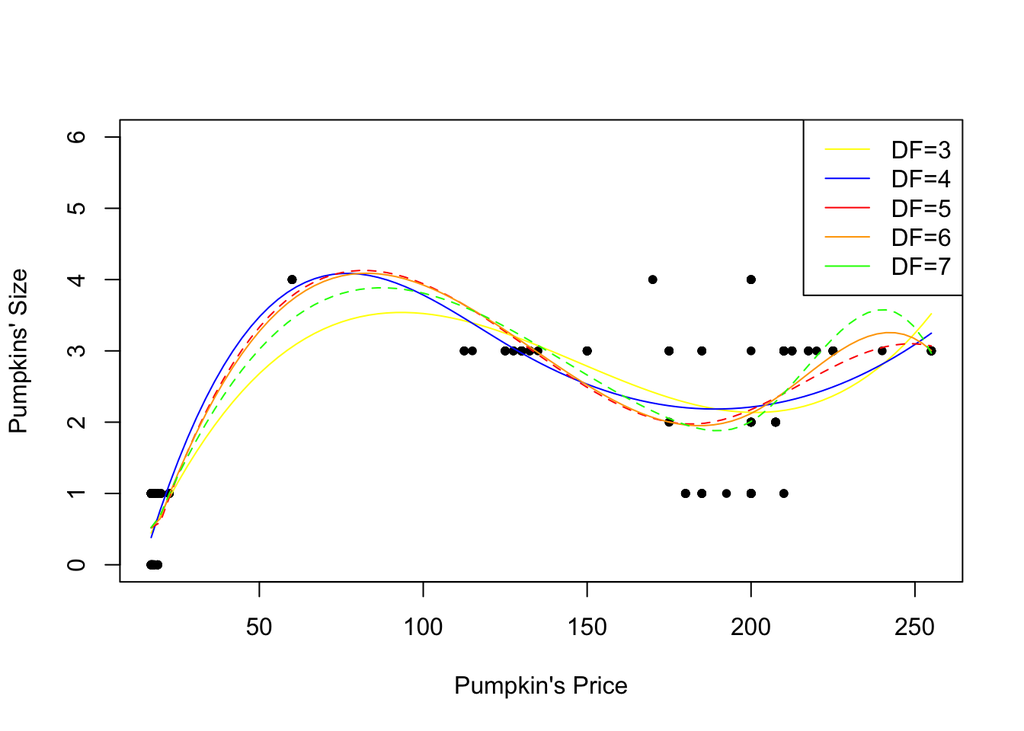

```r
plot(pumpkins$price, pumpkins$size, ylim=c(0,6), pch=20, xlab="Pumpkin's Price", ylab="Pumpkins' Size")
lines(spline(pumpkins$price, predict(pumpkin.bs1)), col="yellow", lty=1)
lines(spline(pumpkins$price, predict(pumpkin.bs2)), col="blue", lty=1)
lines(spline(pumpkins$price, predict(pumpkin.bs3)), col="red", lty=2)
lines(spline(pumpkins$price, predict(pumpkin.bs4)), col="orange", lty=1)
lines(spline(pumpkins$price, predict(pumpkin.bs5)), col="green", lty=2)
legend("topright", lty=rep(1,1,2,1,2), col=c("yellow", "blue", "red", "orange", "green"), legend=c("DF=3","DF=4", "DF=5", "DF=6", "DF=7"))
```

#### Natural Cubic Splines

Of course, instead of B-splines, we can also choose to work with NCS. This can be done as follows:

```r
pumpkin.ncs1 = lm(size ~ ns(price, knots=quantile(price, (1:4)/5)), data=pumpkins)
summary(pumpkin.ncs1)
```

```
##
## Call:
## lm(formula = size ~ ns(price, knots = quantile(price, (1:4)/5)),
##     data = pumpkins)
##
## Residuals:
##     Min      1Q  Median      3Q     Max
## -1.3249 -0.4706 -0.1105  0.5297  1.8704
##
## Coefficients:
##                                              Estimate Std. Error t value
## (Intercept)                                   0.46916    0.09119   5.145
## ns(price, knots = quantile(price, (1:4)/5))1  6.69572    0.60959  10.984
## ns(price, knots = quantile(price, (1:4)/5))2  1.20188    0.37175   3.233
## ns(price, knots = quantile(price, (1:4)/5))3  1.74531    0.16433  10.621
## ns(price, knots = quantile(price, (1:4)/5))4  2.35882    0.27024   8.729
## ns(price, knots = quantile(price, (1:4)/5))5  2.78451    0.23021  12.096
##                                              Pr(>|t|)
## (Intercept)                                  5.54e-07 ***
## ns(price, knots = quantile(price, (1:4)/5))1  < 2e-16 ***
## ns(price, knots = quantile(price, (1:4)/5))2   0.0014 **
## ns(price, knots = quantile(price, (1:4)/5))3  < 2e-16 ***
## ns(price, knots = quantile(price, (1:4)/5))4 4.28e-16 ***
## ns(price, knots = quantile(price, (1:4)/5))5  < 2e-16 ***
## ---
## Signif. codes:  0 '***' 0.001 '**' 0.01 '*' 0.05 '.' 0.1 ' ' 1
##
## Residual standard error: 0.6942 on 242 degrees of freedom
## Multiple R-squared:  0.7084, Adjusted R-squared:  0.7024
## F-statistic: 117.6 on 5 and 242 DF,  p-value: < 2.2e-16
```

```r
dim(ns(pumpkins$price, knots=quantile(pumpkins$price, (1:4)/5)))
```

```
## [1] 248   5
```

OR

```r
pumpkin.ncs2 = lm(size ~ ns(price, df=5), data=pumpkins)
summary(pumpkin.ncs2)
```

```
##
## Call:
## lm(formula = size ~ ns(price, df = 5), data = pumpkins)
##
## Residuals:
##     Min      1Q  Median      3Q     Max
## -1.3249 -0.4706 -0.1105  0.5297  1.8704
##
## Coefficients:
##                    Estimate Std. Error t value Pr(>|t|)
## (Intercept)         0.46916    0.09119   5.145 5.54e-07 ***
## ns(price, df = 5)1  6.69572    0.60959  10.984  < 2e-16 ***
## ns(price, df = 5)2  1.20188    0.37175   3.233   0.0014 **
## ns(price, df = 5)3  1.74531    0.16433  10.621  < 2e-16 ***
## ns(price, df = 5)4  2.35882    0.27024   8.729 4.28e-16 ***
## ns(price, df = 5)5  2.78451    0.23021  12.096  < 2e-16 ***
## ---
## Signif. codes:  0 '***' 0.001 '**' 0.01 '*' 0.05 '.' 0.1 ' ' 1
##
## Residual standard error: 0.6942 on 242 degrees of freedom
## Multiple R-squared:  0.7084, Adjusted R-squared:  0.7024
## F-statistic: 117.6 on 5 and 242 DF,  p-value: < 2.2e-16
```

```r
dim(ns(pumpkins$price, df=5))
```

```
## [1] 248   5
```

We can also plot the NCS and B-Splines for the same DF to see what we get:

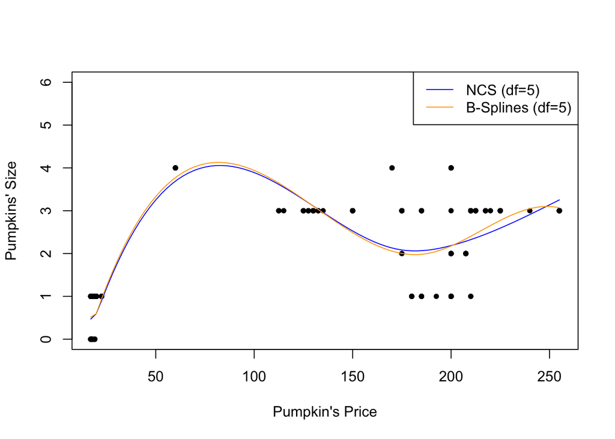

```r
# difference between use of bs and ncs
plot(pumpkins$price, pumpkins$size, ylim=c(0,6), pch=20, xlab="Pumpkin's Price", ylab="Pumpkins' Size")
lines(spline(pumpkins$price, predict(pumpkin.ncs2)), col="blue", lty=1)
lines(spline(pumpkins$price, predict(pumpkin.bs3)), col="orange", lty=1)
legend("topright", lty=rep(1,2), col=c("blue", "orange"), legend=c("NCS (df=5)", "B-Splines (df=5)"))
```

### K-Fold Cross Validation

Last, we are going to use R in order to select the optimal number of knots via K-fold cross validation.

The `caret` library contain a function that allows us to easily create $k$ folds from our data.

```r
library(caret)
   CV_K =c() # initialize the vector to store the CV(k) errors for every fixed knot selection

  for (knots in 3:7) {  # we start with 3 knots and go up to 7 knots

    j=knots-2 # counter index starting at 1
    MSE_i = c()

    for (k in 3:10){   # loop over the number of folds in the data
      i=k-2 # counter index starting at 1
      folds <- createFolds(pumpkins$price, k) # Create the folds

      # Function that fits the model,  computes the MSE of every fold
      results = lapply(folds, function(x){
        pumpkin_train = pumpkins[-x,] # Create train set for fold "x"
        pumpkin_test = pumpkins[x,] # Create corresponding test set.
        pumpkin.bs = lm(size ~ bs(price, knots, intercept=FALSE), data=pumpkin_train) # Fit the model in the train set
        pumpkin.pred = predict(pumpkin.bs, newdata=pumpkin_test) # Test the model in the test set
        mserror = mean( (pumpkin_test$size-pumpkin.pred)^2) # Compute the MSEi for every fold
        return(mserror)
     })
     MSE_i[i] = mean(unlist(results))  # Repeat the previous steps k times
    }

    CV_K[j] = mean(MSE_i) # This is the CV_k for j+2 knots
  }

   CV_K
```

```
## [1] 0.5232160 0.4918207 0.4713699 0.4685606 0.4692828
```

```r
NumberOfKnots = which.min(CV_K) +2
NumberOfKnots
```

```
## [1] 6
```